# Physiological measurements from *R. eutropha* chemostats

08 mars, 2021

## Description

This R notebook contains data and analysis regarding physiological measurements obtained from chemostat cultivations of *Ralstonia eutropha* (a.k.a. *Cupriavidus necator*).

## Libraries

```r
library(lattice)
library(latticeExtra)
library(latticetools)
library(tidyverse)
```

## Chemostat cultivation, biomass and growth rate

### Import and reshape cultivation data

```r
# load chemostat measurements
df_chem <- read.csv("../data/input/20180921_chemostat_OD.csv") %>%

  # remove outlier data points originating from sampling
  filter(!od_value > 0.6) %>%

  # thinning data to reduce file size
  slice_sample(n = 4000)
```

### OD and growth rate

The next step is to plot the OD<sub>720</sub> and growth rate for all cultivations.

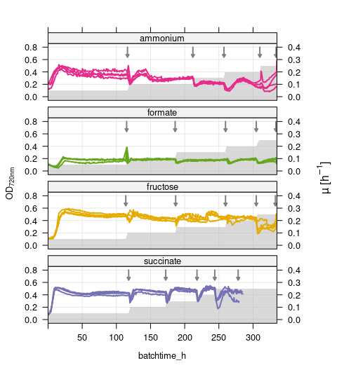

```r
plot_OD <- xyplot(od_value ~ batchtime_h | condition,
  arrange(df_chem, batchtime_h),
  groups = replicate, par.settings = custom.colorblind(),
  layout = c(1,4), as.table = TRUE,
  type = "l", xlim = c(0, 335),
  cols = custom.colorblind()$superpose.polygon$col[1:4],
  between = list(x = 0.5, y = 0.5), lwd = 2,
  ylim = c(-0.06, 0.86), ylab = expression("OD"[720*nm]),
  panel = function(x, y, cols, ...) {
    panel.xyplot(x, y, col = cols[panel.number()], ...)
  }
)

plot_dil <- xyplot(dilution_rate ~ batchtime_h | condition,
  filter(df_chem, replicate == 1),
  par.settings = custom.colorblind(), type = "l",
  between = list(x = 0.5, y = 0.5), ylim = c(-0.03, 0.43),
  xlab = "time [h]", ylab = expression("µ [h"^-1*"]"),
  panel = function(x, y, ...){
    panel.grid(h = -1, v = -1, col = grey(0.9))
    panel.horizonplot(c(x, 335), c(y, max(y)), col.regions = grey(0.7, alpha = 0.5))
    arrow_x <- c(sort(x)[which(diff(sort(y)) != 0)], max(x)-1)
    panel.arrows(x0 = arrow_x, y0 = 0.4, x1 = arrow_x, y1 = 0.32,
      type = "closed", col = grey(0.5), lwd = 2, fill = grey(0.5),
      length = 0.05, unit = "npc")
  }
)

print(doubleYScale(plot_OD, plot_dil, use.style = FALSE, add.ylab2 = TRUE, under = TRUE))
```

### Calculate biomass yield and maintenance

First we summarize average OD and growth rate for all cultivations leaving out the first 25 h batch growth phase.

```r
df_summary <- filter(df_chem, batchtime_h > 25) %>%

  # summarize average OD
  group_by(condition, dilution_rate, replicate) %>%
  summarize(OD720 = mean(od_value, na.rm = TRUE)) %>%

  # then we need medium substrate concentration for FA, FRC, NH4CL, SUC
  mutate(c_substrate = case_when(
    condition == "ammonium" ~ 0.025,
    condition == "formate" ~ 1.0,
    TRUE ~ 0.5
  ))
```

For yield calculations, the residual substrate (mg) needs to be subtracted from feed substrate concentration (g) to determine portion of substrate that is taken up.

```r
df_residual <- read_csv("../data/input/20181116_chemostat_residual_substrate.csv") %>%
  rename(condition = limitation) %>%
  mutate(condition = recode(condition, `formic acid` = "formate", `Nlim - fructose` = "ammonium")) %>%
  mutate(c_residual_g_L = mean_concentration_mg.L/1000 %>% replace(., . < 0, 0))
# join the summary df with residual substrate data
df_summary <- left_join(df_summary, df_residual %>%
    select(condition, dilution_rate, c_residual_g_L) %>%
    filter(!duplicated(c_residual_g_L), condition != "ammonium")) %>%
  mutate(c_residual_g_L = c_residual_g_L %>% replace_na(0))

print(head(df_summary))
```

| condition | dilution_rate | replicate | OD720 | c_substrate | c_residual_g_L |
| --- | --- | --- | --- | --- | --- |
| ammonium | 0.05 | 1 | 0.3210343 | 0.025 | 0 |
| ammonium | 0.05 | 2 | 0.3605266 | 0.025 | 0 |
| ammonium | 0.05 | 3 | 0.4265384 | 0.025 | 0 |
| ammonium | 0.05 | 4 | 0.3771218 | 0.025 | 0 |
| ammonium | 0.10 | 1 | 0.2935762 | 0.025 | 0 |
| ammonium | 0.10 | 2 | 0.2881483 | 0.025 | 0 |

Nest step is to add the DCW in g/L depending on OD and condition. The DCW-OD relationship was determined previously by a master student (Raquel Perruca) using a dilution series. It was found to be `gDCW = 0.5177 * OD_720nm - 0.0108`. The relationship for ammonium-limited cells was redetermined in a separate calibration experiment (2020-07-30, 50 mL shake flask culture), as extreme PHB content in these cells changed light scattering/absorption. The gDCW per OD for ammonium-limitation was corrected based on this result.

We calculate substrate uptake rate q_S with the corrected substrate concentration (S_uptake = S_feed - S_residual). The rate `qS` is then dilution rate times feed concentration divided by biomass in the culture: `qS [g/OD720*L] = D [h-1] * c [g/L] / OD720`. All other following calculations are just variations of OD conversion to gDCW/L, or converting g to C/N-mole.

```r
df_summary <- df_summary %>% mutate(gDCW_L = case_when(
    condition != "ammonium" ~ (0.5177*OD720)-0.0108,
    condition == "ammonium" ~ (0.2766*OD720)-0.0108
  )) %>%

  # substrate uptake rate per OD
  # qS [g/OD720*L] = D [h-1] * c [g/L] / OD720
  mutate(qS_g_OD720 = dilution_rate*(c_substrate-c_residual_g_L)/OD720) %>%

  # substrate uptake rate per gDCW
  # qS [g/gDCW] = D [h-1] * c [g/L] / gDCW * L
  mutate(qS_g_gDCW = dilution_rate*(c_substrate-c_residual_g_L)/gDCW_L) %>%

  # substrate uptake rate in C-mol per C-mol biomass (25.35 gDCW/Cmol = 0.03944 Cmol/gDCW)
  # (source: Grunwald et al., Mirco Biotech, 2015)
  mutate(Cmol_g = case_when(
    condition == "formate" ~ 1/46.03 * 1,
    condition == "fructose" ~ 1/180.16 * 6,
    condition == "succinate" ~ 1/118.09 * 4,
    condition == "ammonium" ~ 1/53.49 * 1 # here it is N-mol! NH4Cl has 1 N
  )) %>%

  # for NH4Cl, we actually use N-mol per N-mol biomass per h.
  # N-mol in biomass is around 4x lower than C mol (bionumbers)
  mutate(qS_Cmol_Cmol_DCW = case_when(
    condition == "ammonium" ~ qS_g_gDCW * Cmol_g / (0.03944/4),
    TRUE ~ qS_g_gDCW * Cmol_g / 0.03944
  ))

head(df_summary)
```

| condition | dilution_rate | replicate | OD720 | c_substrate | c_residual_g_L | gDCW_L | qS_g_OD720 | qS_g_gDCW | Cmol_g | qS_Cmol_Cmol_DCW |
| --- | --- | --- | --- | --- | --- | --- | --- | --- | --- | --- |
| ammonium | 0.05 | 1 | 0.3210343 | 0.025 | 0 | 0.07799810 | 0.003893664 | 0.01602603 | 0.01869508 | 0.03038621 |
| ammonium | 0.05 | 2 | 0.3605266 | 0.025 | 0 | 0.08892167 | 0.003467150 | 0.01405732 | 0.01869508 | 0.02665342 |
| ammonium | 0.05 | 3 | 0.4265384 | 0.025 | 0 | 0.10718053 | 0.002930568 | 0.01166257 | 0.01869508 | 0.02211284 |
| ammonium | 0.05 | 4 | 0.3771218 | 0.025 | 0 | 0.09351188 | 0.003314579 | 0.01336729 | 0.01869508 | 0.02534508 |
| ammonium | 0.10 | 1 | 0.2935762 | 0.025 | 0 | 0.07040318 | 0.008515676 | 0.03550976 | 0.01869508 | 0.06732839 |
| ammonium | 0.10 | 2 | 0.2881483 | 0.025 | 0 | 0.06890183 | 0.008676087 | 0.03628351 | 0.01869508 | 0.06879546 |

```r
HP_plot <- function(data, xlimits = c(0, 0.3), ylimits = c(0, 1)) {
  xyplot(qS_g_gDCW ~ dilution_rate | condition, data,
    par.settings = custom.lattice, lwd = 1.5,
    xlim = xlimits, ylim = ylimits,
    ylab = expression("q"[S]*" [g h"^-1*" gDCW"^-1*"]"),
    xlab = expression('µ [h'^'-1'*']'),
    panel = function(x, y, ...) {
      panel.grid(h = -1, v = -1, col = grey(0.9))
      panel.xyplot(x, y, cex = 0.9, ...)
      # regression line through linear part of the data (omit µ = 0.25/h)
      sel <- x != 0.25; x = x[sel]; y = y[sel]
      panel.lmlineq(x, y, fontfamily = "FreeSans",
        pos = 3, offset = 7, r.squared = TRUE, cex = 0.7, col.text = grey(0.3), ...)
      coef <- lm(y ~ x, data.frame(x, y))$coeff
      # displaying maintenance and yield coefficients
      panel.abline(h = coef[[1]], lty = 2, ...)
      panel.text(0.15, coef[[1]],
        paste("ms =", round(coef[[1]], 3), "g h-1 gDCW-1"),
        col = grey(0.3), pos = 3, cex = 0.7)
      panel.text(0.15, coef[[1]], paste(expression("Yx/S ="),
        round(1/coef[[2]], 3), "gDCW g-1"),
        col = grey(0.3), pos = 1, cex = 0.7)
    }
  )
}

print(HP_plot(data = filter(df_summary, condition == "formate"),
  ylimits = c(-7/4, 7)), split = c(1,1,2,2), more = TRUE)
print(HP_plot(data = filter(df_summary, condition == "fructose"),
  ylimits = c(-1.5/4, 1.5)), split = c(2,1,2,2), more = TRUE)
```

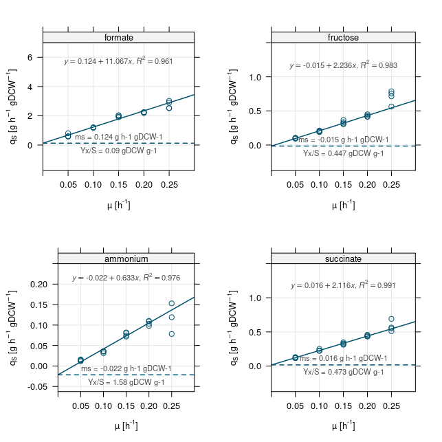

```r
print(HP_plot(data = filter(df_summary, condition == "ammonium"),
  ylimits = c(-0.25/4, 0.25)), split = c(1,2,2,2), more = TRUE)
print(HP_plot(data = filter(df_summary, condition == "succinate"),
  ylimits = c(-1.5/4, 1.5)), split = c(2,2,2,2))
```

A similar plot could be made for C-mole and N-mole per C-mole biomass instead of [gram] units. Since the data is similar and only the units change, we just extract the slope and intercept of the four linear models for each substrate.

```r
get_lm_coeff <- function(x, y) {
  linmod <- lm(y ~ x, data.frame(x = x, y = y))
  c(round(linmod$coeff[[1]], 3), round(1/linmod$coeff[[2]], 3))
}
df_summary %>% group_by(condition) %>%
  summarize(value = get_lm_coeff(dilution_rate, qS_Cmol_Cmol_DCW)) %>%
  ungroup %>%
  mutate(variable = rep(c("mS [Cmole Cmole_DCW-1 h-1]", "Yx/S [Cmole DCW Cmole-1]"), 4))
```

| condition | value | variable |
| --- | --- | --- |
| ammonium | -0.058 | mS [Cmole Cmole_DCW-1 h-1] |
| ammonium | 0.726 | Yx/S [Cmole DCW Cmole-1] |
| formate | 0.101 | mS [Cmole Cmole_DCW-1 h-1] |
| formate | 0.173 | Yx/S [Cmole DCW Cmole-1] |
| fructose | -0.067 | mS [Cmole Cmole_DCW-1 h-1] |
| fructose | 0.411 | Yx/S [Cmole DCW Cmole-1] |
| succinate | 0.002 | mS [Cmole Cmole_DCW-1 h-1] |
| succinate | 0.517 | Yx/S [Cmole DCW Cmole-1] |

### Biomass, residual substrate

This is just an auxiliary plot for the cultivation overview of OD and growth rate from above. In this plot, the average biomass concentration is shown per condition.

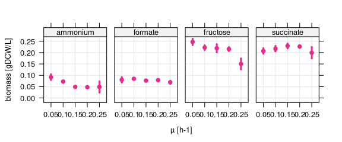

```r
xyplot(gDCW_L ~ factor(dilution_rate) | condition, df_summary,
  as.table = FALSE, xlab = "µ [h-1]", ylab = "biomass [gDCW/L]",
  between = list(x = 0.7, y = 0.7),
  scales = list(alternating = FALSE), lwd = 3,
  par.settings = custom.colorblind(), layout = c(4, 1),
  pch = 19, ylim = c(-0.02, 0.27),
  panel = function(x, y, ...) {
    panel.grid(h = -1, v = -1, col = grey(0.9))
    panel.errbars(x, y, ewidth = 0, ...)
  }
)
```

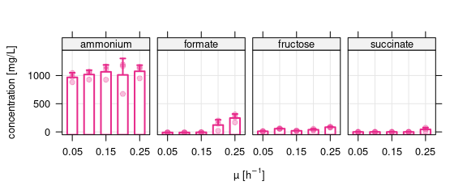

```r
plot_residual <- xyplot(concentration_mg.L ~ factor(dilution_rate) | condition,
  df_residual,
  par.settings = custom.colorblind(), as.table=TRUE,
  pch = 19, ylim = c(-50, 1450), layout = c(4, 1),
  between = list(x = 0.5, y = 0.5),
  scales = list(alternating = FALSE, x = list(at = c(1,3,5))),
  xlab = expression("µ [h"^-1*"]"), ylab = "concentration [mg/L]",
  panel = function(x, y, ...) {
    panel.grid(h = -1, v = -1, col = grey(0.9))
    panel.barplot(x, y, ewidth = 0.3, lwd = 2, fill = "white", fill_alpha = 1, ...)
    panel.xyplot(x, y, alpha = 0.3, ...)
  }
)

print(plot_residual)
```

## PHB content of cells

The following section analyzes data obtained from chemostat cultivations of the *R. eutropha* wild type (WT, PHB+) and a PHB knockout mutant (PHB-) obtained by random mutagenesis. Both strains were cultivated in chemostats with stepwise increase of dilutiuon rate (equals growth rate). Different parameters of these cultivations were determined among, those poly-hydroxybutyrate (PHB) content. PHB content was determined using Nile red staining (relative, not absolute quantification).

First we import PHB quantification data per growth rate.

```r
df <- read_csv("../data/input/20190716_chemostat_PHB.csv")
```

Next we reshape and filter the data a bit.

```r
df <- filter(df, mu <= 0.3) %>%
  mutate(condition = recode(
    condition, "C-limitation" = "fructose", "N-limitation" = "ammonium")) %>%

  mutate(replicate = if_else(channel > 4, channel-4, channel))

head(df)
```

| exp_id | exp_start | channel | strain | condition | c_Frc [g/l] | c_NH4Cl [g/l] | mu | OD720_ext | V_nr [ml] | OD720_nr | I_nr | V_DCW [ml] | DCW [g/ml] | replicate |
| --- | --- | --- | --- | --- | --- | --- | --- | --- | --- | --- | --- | --- | --- | --- |
| 1 | 16/07/2019 | 1 | PHB+ | fructose | 0.5 | 1.00 | 0.05 | NA | 2 | 0.6181607 | 1116815.3 | NA | NA | 1 |
| 1 | 16/07/2019 | 2 | PHB+ | fructose | 0.5 | 1.00 | 0.05 | NA | 2 | 0.6298067 | 1828995.7 | NA | NA | 2 |
| 1 | 16/07/2019 | 3 | PHB- | fructose | 0.5 | 1.00 | 0.05 | NA | 2 | 0.4519745 | 561667.3 | NA | NA | 3 |
| 1 | 16/07/2019 | 4 | PHB- | fructose | 0.5 | 1.00 | 0.05 | NA | 2 | 0.4390346 | 338628.0 | NA | NA | 4 |
| 1 | 16/07/2019 | 5 | PHB+ | ammonium | 2.0 | 0.05 | 0.05 | NA | 1 | 0.6767603 | 8012680.0 | NA | NA | 1 |
| 1 | 16/07/2019 | 6 | PHB+ | ammonium | 2.0 | 0.05 | 0.05 | NA | 1 | 0.8394341 | 7951457.7 | NA | NA | 2 |

Then we plot relative PHB content over growth rate. In a second step we *estimate* absolute PHB content by using data from the literature as help. We can set the maximum observed Nile Red fluorescence to the average relative PHB content obtained under N limitation as reported in the literature. For example Steinbuechel & Schlegel, AMB, 1989 reported a PHB content of 0.4 g/g protein under N-limitation. With 0.65 g protein/gDCW, that equals 0.4 x 0.65 = 0.26 g/gDCW PHB. A second reference, Wu *et al*., Kor J Chem Eng, 2009, determined that up to 41.8% biomass is PHB (= 0.41 g/gDCW).

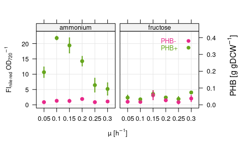

```r
plot_NR_fluorescence <- xyplot(I_nr/OD720_nr/10^6 ~ factor(mu) | condition,
  df, groups = strain,
  par.settings = custom.colorblind(),
  pch = 19, lwd = 2,
  as.table = TRUE, between = list(x = 0.5, y = 0.5),
  xlab = expression("µ [h"^-1*"]"),
  ylab = expression("FI"["nile red"]*" OD"[720]*""^-1),
  scales = list(alternating = FALSE),
  panel=function(x, y, ...) {
    panel.grid(h = -1, v = -1, col = grey(0.9))
    panel.errbars(x, y, ewidth = 0, ...)
    panel.key(..., which.panel = 2, corner = c(0.9, 0.9))
  }
)


df <- df %>% mutate(
  rel_PHB_g_gDCW = I_nr/OD720_nr/max(I_nr/OD720_nr)*0.41
)

plot_rel_PH_content <- xyplot(rel_PHB_g_gDCW ~ factor(mu) | condition,
  df, groups = strain,
  ylab = expression("PHB [g gDCW"^-1*"]"),
  panel=function(x, y, ...) {
    panel.errbars(x, y, ewidth = 0, ...)
  }
)

doubleYScale(plot_NR_fluorescence,
  plot_rel_PH_content, use.style = FALSE, add.ylab2 = TRUE) %>% print
```

## O<sub>2</sub> consumption and CO<sub>2</sub> emission

Outlet gas composition was analyzed with specific optical sensors for O<sub>2</sub> and CO<sub>2</sub>. The gas uptake rate can then be determined knowing the input concentration, output concentration, flow rate per reactor, and biomass concentration per reactor. First load raw measurement data.

```r
df_gas <- read_csv("../data/input/20190728_chemostat_gas.csv")
```

Next we summarize all measurements to one measurement per condition and replicate. Then we use measurements for the replicates to calculate the mean gas uptake and emission rate normalized to biomass concentration.

```r
df_gas <- df_gas %>%

  # remove mu higher than 0.3
  filter(mu <= 0.3) %>%

  # determine average delta air flow per cond and replicate
  group_by(condition, strain, mu, type, channel, `flow_rate [ml/min]`) %>%
  summarize(flow_mL_min = mean(`flow [ml/min]`)) %>%

  # renumber replicates from 1 to n
  group_by(condition, strain, mu, type) %>%
  mutate(replicate = seq_along(channel)) %>%
  arrange(condition, strain, mu, type, replicate) %>%

  # obtain biomass concentration from first table
  ungroup %>% left_join(
    group_by(df, strain, condition, mu) %>%
    summarize(gDCW_mL = mean(`DCW [g/ml]`, na.rm = TRUE)) %>%
    ungroup
    )
```

Now that we have the biomass concentration in gDCW/mL, we can determine the CO<sub>2</sub> emission and O<sub>2</sub>. The culture volume is 65 mL and the mass per volume CO<sub>2</sub> is 1.842 mg/mL (air at 1 atm and 20 °C). The mass per volume O<sub>2</sub> is 1.314 mg/mL (air at 1 atm and 20 °C) The CO<sub>2</sub> emission rate can then be calculated as:

```r
df_gas <- df_gas %>%

  # add volume to mass conversion
  mutate(m_gas_mg_mL = if_else(type == "CO2", 1.842, 1.314)) %>%

  mutate(
  q_mL_min_gDCW = flow_mL_min / (gDCW_mL * 65),
  q_g_h_gDCW = q_mL_min_gDCW * m_gas_mg_mL * 60 / 1000
  )

head(df_gas)
```

| condition | strain | mu | type | channel | flow_rate [ml/min] | flow_mL_min | replicate | gDCW_mL | m_gas_mg_mL | q_mL_min_gDCW | q_g_h_gDCW |
| --- | --- | --- | --- | --- | --- | --- | --- | --- | --- | --- | --- |
| ammonium | PHB- | 0.05 | CO2 | 7 | 80 | 0.02250933 | 1 | NaN | 1.842 | NaN | NaN |
| ammonium | PHB- | 0.05 | CO2 | 8 | 80 | 0.02003200 | 2 | NaN | 1.842 | NaN | NaN |
| ammonium | PHB- | 0.05 | O2 | 7 | 80 | -0.02776667 | 1 | NaN | 1.314 | NaN | NaN |
| ammonium | PHB- | 0.05 | O2 | 8 | 80 | -0.02176667 | 2 | NaN | 1.314 | NaN | NaN |
| ammonium | PHB- | 0.10 | CO2 | 7 | 80 | 0.01684267 | 1 | 6.5e-05 | 1.842 | 3.986430 | 0.4405802 |
| ammonium | PHB- | 0.10 | CO2 | 8 | 80 | 0.02493333 | 2 | 6.5e-05 | 1.842 | 5.901381 | 0.6522206 |

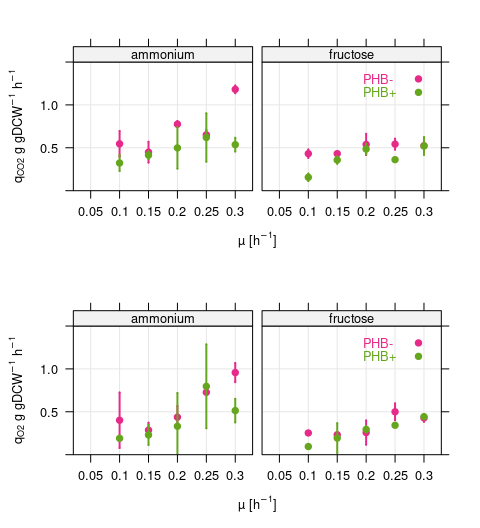

```r
plot_CO2_em <- xyplot(q_g_h_gDCW ~ factor(mu) | condition,
  filter(df_gas, type == "CO2"), groups = strain,
  par.settings = custom.colorblind(),
  pch = 19, lwd = 2, ylim = c(0, 1.5),
  as.table = TRUE, between = list(x = 0.5, y = 0.5),
  xlab = expression("µ [h"^-1*"]"),
  ylab = expression("q"[CO2]*" g gDCW"^-1*" h"^-1),
  scales = list(alternating = FALSE),
  panel=function(x, y, ...) {
    panel.grid(h = -1, v = -1, col = grey(0.9))
    panel.errbars(x, y, ewidth = 0, ...)
    panel.key(..., which.panel = 2, corner = c(0.9, 0.9))
  }
)

plot_O2_up <- xyplot(q_g_h_gDCW*-1 ~ factor(mu) | condition,
  filter(df_gas, type == "O2"), groups = strain,
  par.settings = custom.colorblind(),
  pch = 19, lwd = 2, ylim = c(0, 1.5),
  as.table = TRUE, between = list(x = 0.5, y = 0.5),
  xlab = expression("µ [h"^-1*"]"),
  ylab = expression("q"[O2]*" g gDCW"^-1*" h"^-1),
  scales = list(alternating = FALSE),
  panel=function(x, y, ...) {
    panel.grid(h = -1, v = -1, col = grey(0.9))
    panel.errbars(x, y, ewidth = 0, ...)
    panel.key(..., which.panel = 2, corner = c(0.9, 0.9))
  }
)

print(plot_CO2_em, split = c(1,1,1,2), more = TRUE)
print(plot_O2_up, split = c(1,2,1,2))
```

## High throughput imaging of chemostat cultivated cells

The same samples as were used to determine bulk PHB content using nile red fluorescence spectroscopy were also subjected to high throughput imaging. A Nikon microscope was used to acquire up to 5-10 images per replicate and condition. Phase contrast images and Texas Red fluorescence were acquired to identify cell outline/shape and Nile red fluorescnce from PHB staining, respectively. A custom Cell Profiler pipeline was used to automatically identfy cells, filter out non-cell objects by shape/size, and quantify fluorescence.

First we load a processed data frame combining data of fructose and ammonium limitation.

```r
df_imaging <- read_csv("../data/input/20190728_chemostat_imaging.csv")
```

Now we can plot the length of the cells and the volume calculated from the major axis length, and from the assumption that cells are rod/cylinder shaped objects. More precisely, cell volume using the volume of a cylinder as model was determined using the height h, (longest/major axis of our cell image), and its radius r (half of the minor axis/diameter of our cells). Then, volume is calculated as V = pi x r^2 x h.

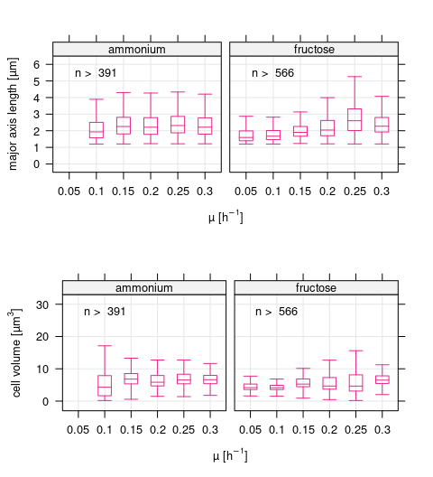

```r
# see graph pars "box.rectangle" for the box, "box.umbrella" for whiskers
cell_length <- xyplot(MajorAxisLength_um ~ factor(Metadata_mu) | limitation,
  df_imaging %>% filter(strain == "WT (PHB+)"),
  par.settings = custom.colorblind(),
  scales = list(alternating = FALSE),
  xlab = expression("µ [h"^-1*"]"),
  ylab = expression("major axis length [µm]"),
  lwd = 3, ylim = c(-0.5, 6.5),
  as.table = TRUE, between = list(x = 0.5, y = 0.5),
  panel=function(x, y, ...) {
    panel.grid(h = -1, v = -1, col = grey(0.9))
    panel.bwplot(x, y, horizontal = FALSE, pch = "|",
      notch = FALSE, do.out = FALSE, ...)
    n_cells = tapply(y, x, length)
    panel.text(labels = paste("n > ", min(n_cells, na.rm = TRUE)-1), x = 2, y = 5.5)
    #lm(y ~ x, data.frame(x = x, y= y)) %>% summary %>% print
  }
)

cell_volume <- xyplot(cell_volume_um3 ~ factor(Metadata_mu) | limitation,
  df_imaging %>% filter(strain == "WT (PHB+)"),
  par.settings = custom.colorblind(),
  scales = list(alternating = FALSE),
  xlab = expression("µ [h"^-1*"]"),
  ylab = expression("cell volume [µm"^3*"]"),
  lwd = 3, ylim = c(-3, 33),
  as.table = TRUE, between = list(x = 0.5, y = 0.5),
  panel=function(x, y, ...) {
    panel.grid(h = -1, v = -1, col = grey(0.9))
    panel.bwplot(x, y, horizontal = FALSE, pch = "|",
      notch = FALSE, do.out = FALSE, ...)
    n_cells = tapply(y, x, length)
    panel.text(labels = paste("n > ", min(n_cells, na.rm = TRUE)-1), x = 2, y = 28)
    #lm(y ~ x, data.frame(x = x, y= y)) %>% summary %>% print
  }
)

print(cell_length, split = c(1,1,1,2), more = TRUE)
print(cell_volume, split = c(1,2,1,2))
```